# A brief introduction to the likelihood

Aaron A. King

For your convenience, the **R** codes for this document are provided in a script which you can download, edit, and run.

## The likelihood

We have seen that fitting mechanistic models to data is a powerful and general approach to estimating parameters. We saw too that least-squares fitting is a straightforward way to do this. However, several issues arose. First, there was an element of arbitrariness in the choice of discrepancy measure. Second, although we could fairly easily obtain point estimates of model parameters using least-squares, it was not clear how we could obtain concomitant estimates of parameter uncertainty (e.g., confidence intervals). Finally, we began to see that there are limits to our ability to estimate parameters. In this lab, we’ll explore these issues, and see that likelihood offers an attractive resolution to the first and second of these, but that the third is a fundamental challenge.

Likelihood has many advantages:

1. fidelity to model
2. a deep and general theory
3. a sound theoretical basis for confidence intervals and model selection
4. statistical efficiency

and some disadvantages:

1. fidelity to model
2. fragility (lack of robustness)

The method of maximum likelihood was introduced by Fisher (1922). A good general reference on likelihood is by Pawitan (2001).

## Definition

Likelihood is the *probability of a given set of data $D$ having occurred under a particular hypothesis $H$*:
$$\mathcal{L}(H,D)=\mathbb{P}\left[{D|H}\right]$$

A simple example: suppose $n$ individuals participate in a serological survey and $k$ of these individuals are found to be seropositive. One parameter of interest is the true fraction, $p$, of the population that has seroconverted. Assuming the sample was drawn at random and the population is large, then the probability of the data ($m$ of $n$ individuals seropositive) given the hypothesis that the true probability is $p$ is
$$\mathbb{P}\left[{D|H}\right] = \binom{n}{k}\,p^k\,(1-p)^{n-k}.$$

If the true seroprevalence was, say, $p=0.3$, what does the probability of observing $k$ seropositives in a sample of size $n=50$ look like?

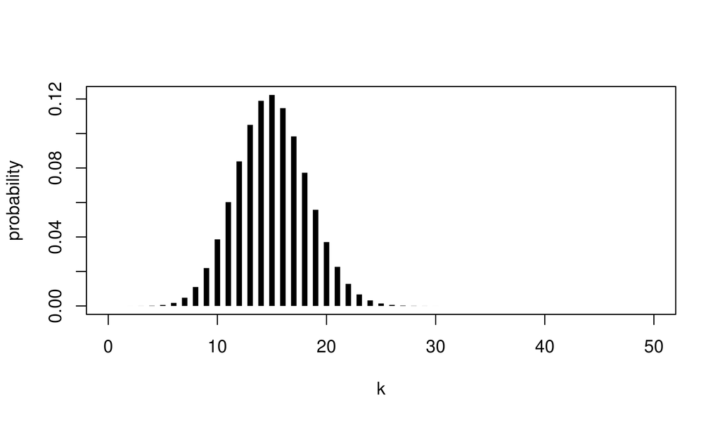

```r
p <- 0.3
n <- 50
k <- seq(0,50,by=1)
prob <- dbinom(x=k,size=n,prob=p)
plot(k,prob,type='h',lwd=5,lend=1,
     ylab="probability")
```

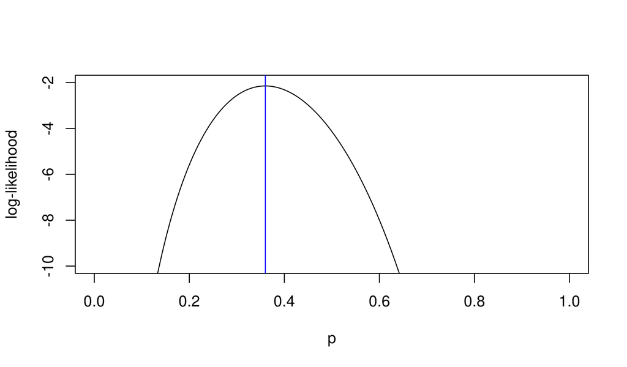

```r
k1 <- 18
n1 <- 50
p <- seq(0,1,by=0.001)
plot(p,dbinom(x=k1,size=n1,prob=p,log=TRUE),
     ylim=c(-10,-2),ylab="log-likelihood",
     type='l')
abline(v=k1/n1,col='blue')
```

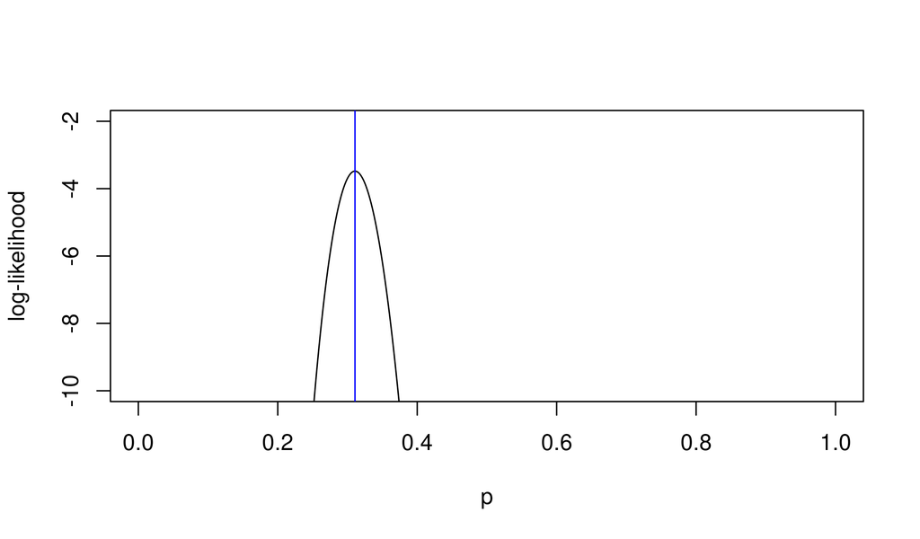

```r
k2 <- 243
n2 <- 782
p <- seq(0,1,by=0.001)
plot(p,dbinom(x=k2,size=n2,prob=p,log=TRUE),
     ylim=c(-10,-2),ylab="log-likelihood",
     type='l')
abline(v=k2/n2,col='blue')
```

In the above two plots, the likelihood is a function of the model parameter $p$. Vertical lines show the maximum likelihood estimate (MLE) of $p$.

#### Exercise: interpreting the likelihood

How do the two curves just plotted differ from one another? What features of the data are responsible for the differences?

## From data points to data sets

Let’s suppose we have three samples, $D_1, D_2, D_3$, taken by three different researchers, for the same large population. If these samples are *independent*, then
$$\mathbb{P}\left[{D|H}\right] = \mathbb{P}\left[{D_1|H}\right]\times\mathbb{P}\left[{D_2|H}\right]\times\mathbb{P}\left[{D_3|H}\right],$$
which means that the likelihood of the full data set is the product of the likelihoods from each of the samples. In other words, the likelihood gives a general recipe for combining data from independent studies. We’d compute the likelihood as follows:

```r
n <- c(13,484,3200)
k <- c(4,217,1118)
dbinom(x=k,size=n,prob=0.2,log=TRUE)
```

```
[1]   -1.873761  -79.243371 -197.561806
```

```r
sum(dbinom(x=k,size=n,prob=0.2,log=TRUE))
```

```
[1] -278.6789
```

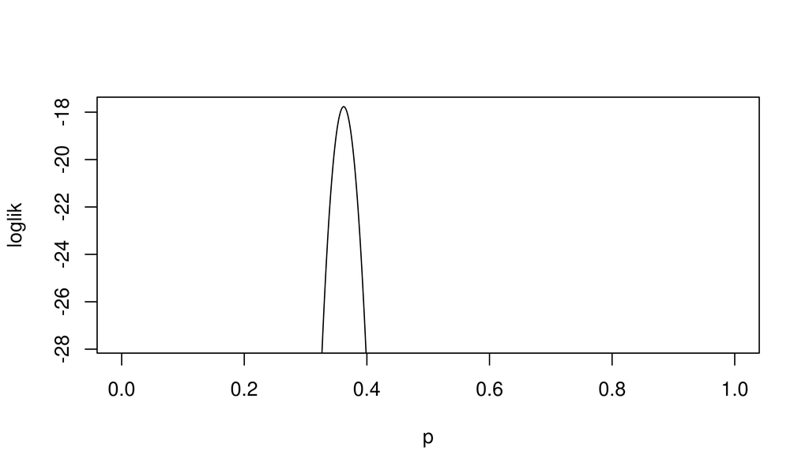

```r
ll.fn <- function (p) {
  sum(dbinom(x=k,size=n,prob=p,log=TRUE))
}
p <- seq(0,1,by=0.001)
loglik <- sapply(p,ll.fn)
plot(p,loglik,type='l',ylim=max(loglik)+c(-10,0))
```

## References

Fisher RA (1922). “On the Mathematical Foundations of Theoretical Statistics.” *Philos Trans R Soc London A*, **222**, 309–368. https://doi.org/10.1098/rsta.1922.0009.

Pawitan Y (2001). *In All Likelihood: Statistical Modelling and Inference Using Likelihood*. Clarendon Press, Oxford.

Licensed under the [Creative Commons Attribution-NonCommercial license](http://creativecommons.org/licenses/by-nc/4.0/). Please share and remix noncommercially, mentioning its origin.